# BG3, S2 and central nervous system cells analysis

Patrycja Rosa

22 December 2020

> Compile with `Rscript -e 'rmarkdown::render("src/Rmd/cns_report.Rmd")'`

RNA sequencing data came from the study of Cherbas et al. “The transcriptional diversity of 25 Drosophila cell lines” (Genome Res. 2011 Feb; 21(2): 301–314) and from the Gambetta lab.

The data were subjected to pre-processing, filtering and normalization. Linear (Principal Component Analysis) dimensionality reduction methods was applied. The statistical analysis was based on the negative binomial regression, with empirical Bayes parameter estimation and quasi-likelihood F-test. Multiple testing problem was addressed by using Benjamini-Hochberg correction method. The computational analysis was made using edgeR library. Library biomaRt was used to get gene names and chromosome locations. Ggplot2, VennDiagram, pheatmap and RColorBrewer libraries were used for visualization of the results.

### Table with gene numbers

| Gene set | Count |
| --- | --- |
| Input genes | 17,512 |
| Genes after removing low-expressed ones using edgeR::filterByExpr | 9,356 |

### Principal Component. Analysis

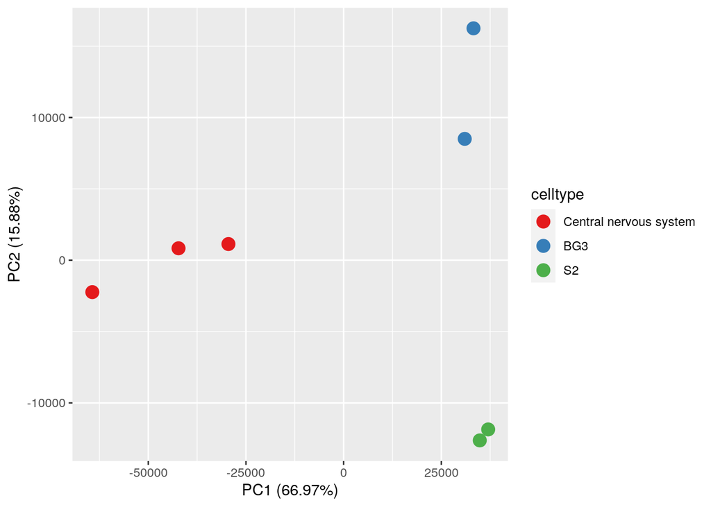

### Numbers of differentialy expressed genes

| Gene set | Count |
| --- | --- |
| Genes tested for differential expression | 9,356 |
| Central nervous system vs S2 (FDR 0.05) | 7,013 |
| Central nervous system vs BG3 (FDR 0.05) | 6,538 |
| BG3 vs S2 (FDR 0.05) | 3,863 |

Only the following set of differentialy expressed genes having absolute log<sub>2</sub> fold change > 2 were further considered:

| Gene set | Count |
| --- | --- |
| Central nervous system vs S2 (FDR 0.05, abs. logFC > 2) | 3,437 |
| Central nervous system vs BG3 (FDR 0.05, abs. logFC > 2) | 2,991 |
| BG3 vs S2 (FDR 0.05, abs. logFC > 2) | 1,592 |

### Venn Diagram for three contrasts

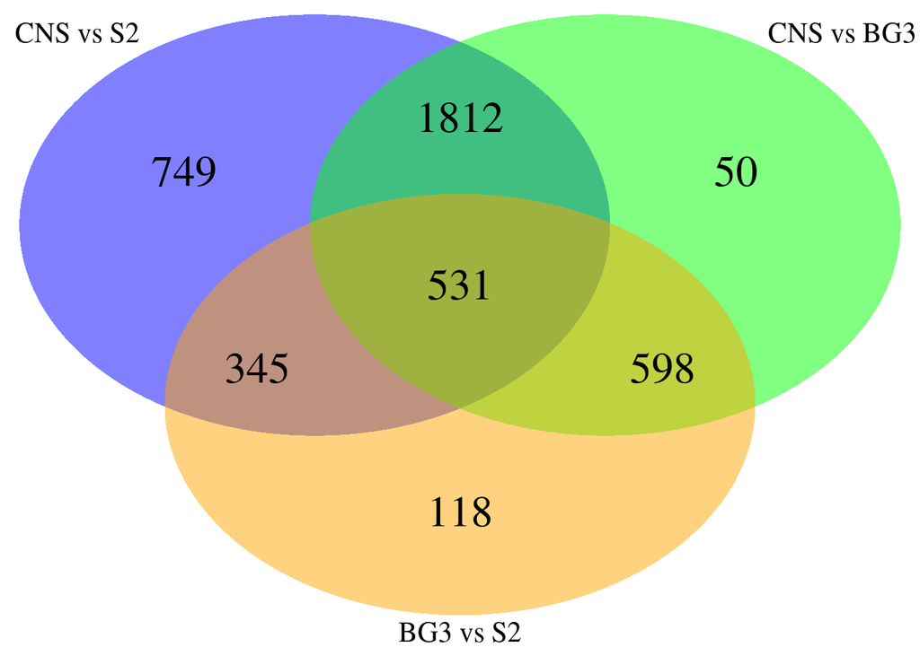

### Differences in gene expression level between central nervous system cells and S2 cells

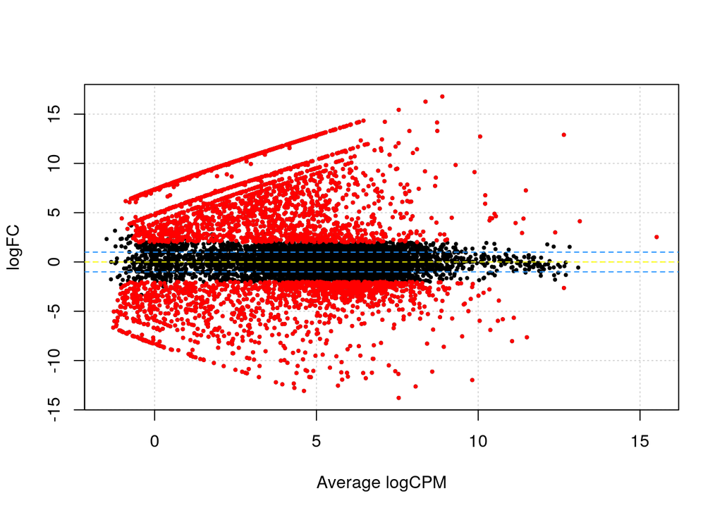

### Differences in gene expression level between central nervous system cells and BG3 cells

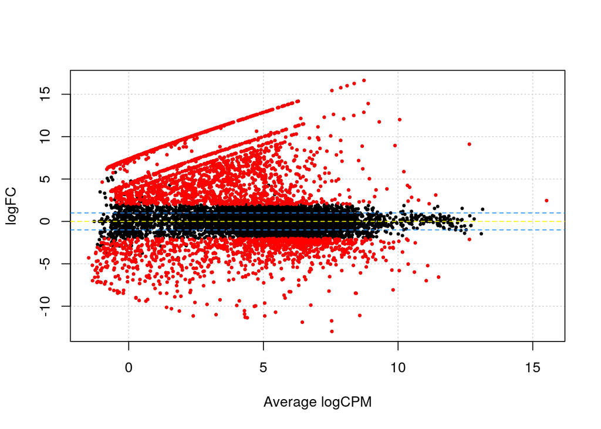

### Differences in gene expression level between BG3 and S2 cells

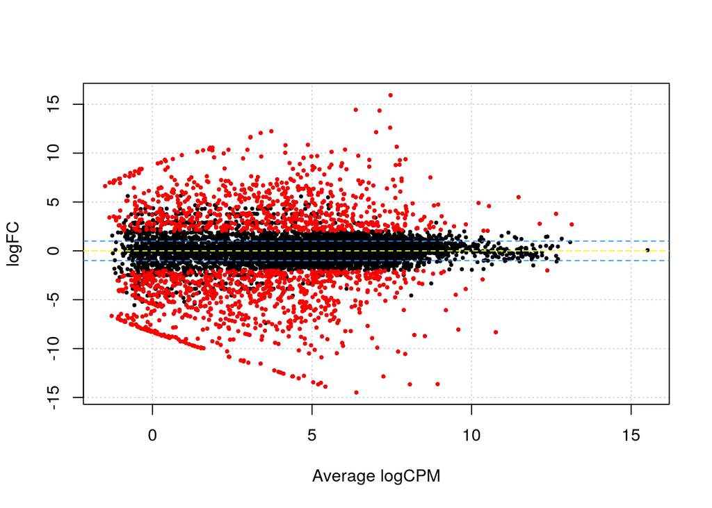

### Expression levels for differentialy expressed genes in central nervous system vs S2

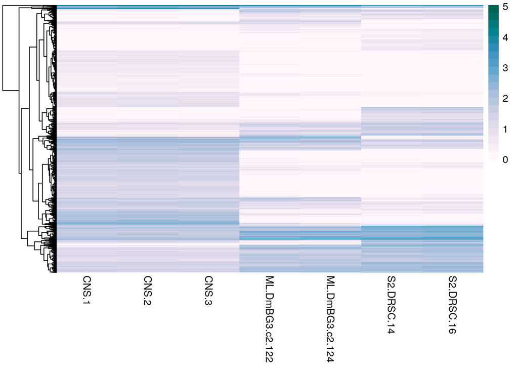

### Expression levels for differentialy expressed genes in central nervous system vs BG3

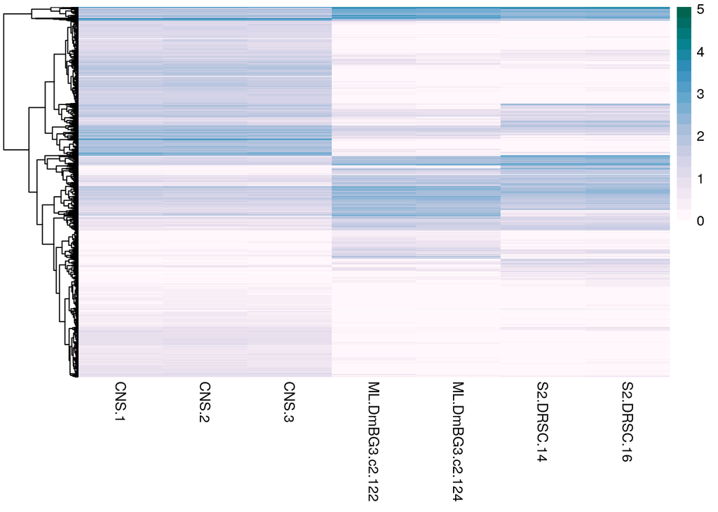

### Expression levels for differentialy expressed genes in BG3 vs S2

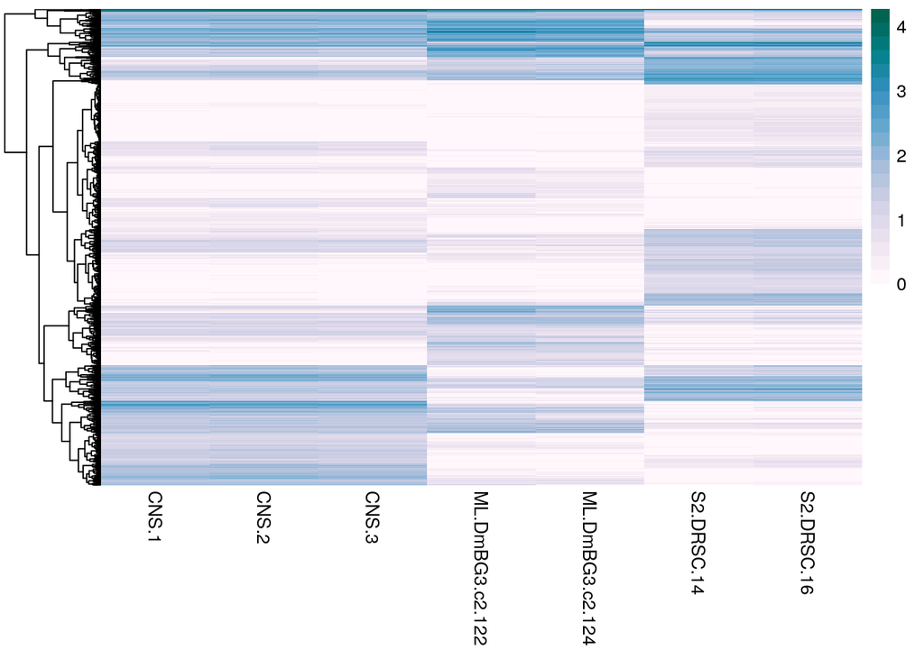

### Expression levels for 50 differentialy expressed genes with the highest value of log fold change in central nervous system vs S2 contrast

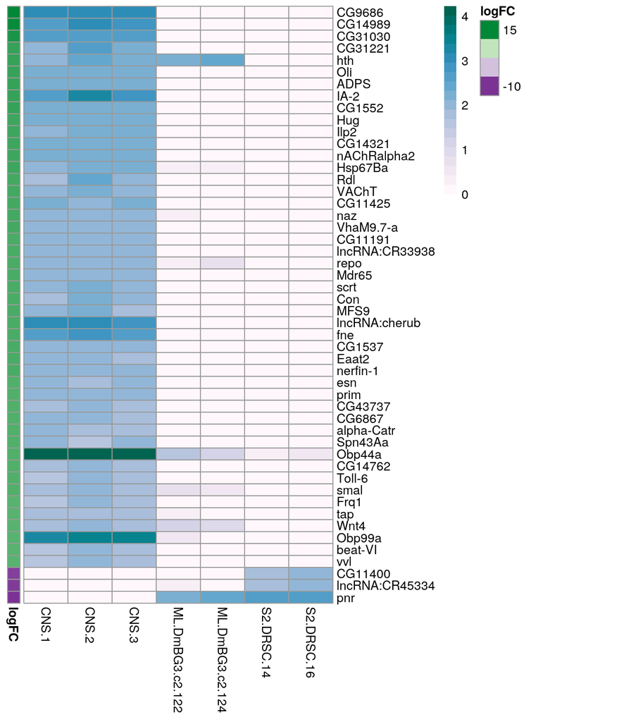

### Expression levels for 50 differentialy expressed genes with the highest value of log fold change in central nervous system vs BG3 contrast

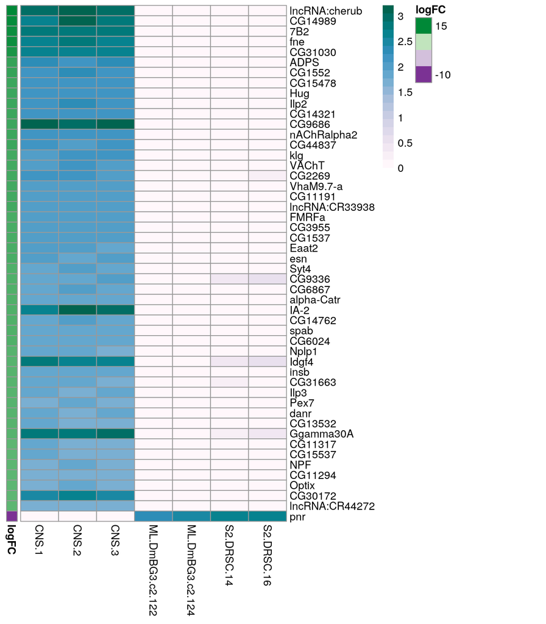

### Expression levels for 50 differentialy expressed genes with the highest value of log fold change in BG3 vs S2 contrast

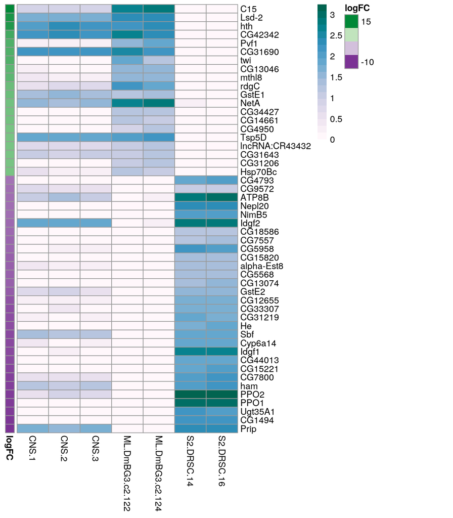